# BlandAltman

[figure not shown]

**Collaborators**

none

*Awesome Biobank Study Team*

Sander W. van der Laan, Anita Study, Sjaak Ethicus, Liv Bio.

**Project ID**

BlandAltman

## Background

Example code of the Bland-Altman test with some figures. This example also serves the purpose to show the some key-elements for a GitHub repository:

- a `readme`, like this one with some background information.
- a `scripts` folder which holds some additional scripts.
- an `images` folder for some images one can use anywhere, like in this `readme`.
- a proper `LICENSE` file.
- a proper `.gitignore` file.
- a `renv`-lock file to facilitate project-local R dependency management to projects. Refer to https://rstudio.github.io/renv/articles/renv.html for more information.

This example repository is further based on the `WORCS` package as described below which is a full featured package to facilitate and maximize the Open Science practices in project management.

### Objectives

To apply the Bland-Altman test.

### Study population

Randomly generated dataset.

### Statistical analysis

Regular Bland-Altman test.

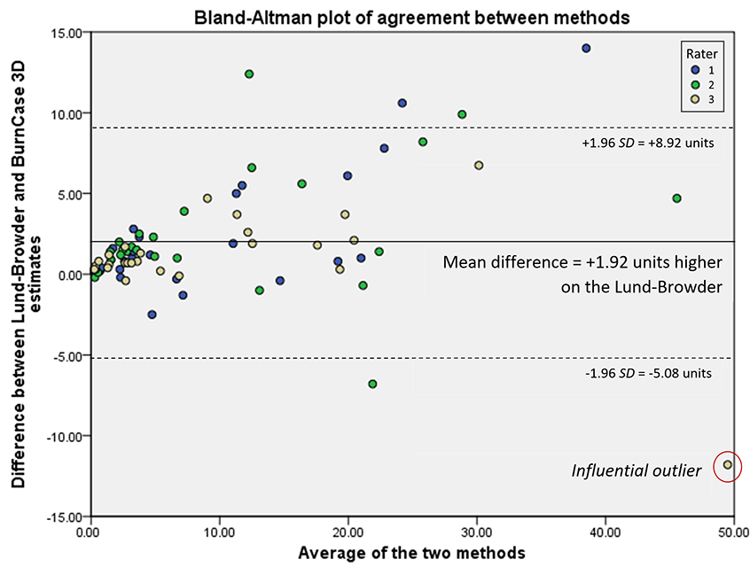

Bland-Altman plot

**Bland-Altman plot of 3 clinicians’ ratings of burn size, using two different methods.** This image was taken from [Wiki](https://commons.wikimedia.org/wiki/File:Bland-altman_plot_of_three_clinicians%27_ratings_of_burn_size,_using_two_different_methods.png).

## Where do I start?

You can load this project in RStudio by opening the file called ‘BlandAltman.Rproj’.

## Project structure

| File | Description | Usage |
| --- | --- | --- |
| README.md | Description of project | Human editable |
| BlandAltman.Rproj | Project file | Loads project |
| LICENSE | User permissions | Read only |
| .worcs | WORCS metadata YAML | Read only |
| renv.lock | Reproducible R environment | Read only |
| bland_altman | Location of output | Human editable |
| images | Location of images | Read only |
| scripts | Location of scripts | Read only |

# Reproducibility

This project uses the Workflow for Open Reproducible Code in Science (WORCS) to ensure transparency and reproducibility. The workflow is designed to meet the principles of Open Science throughout a research project.

To learn how WORCS helps researchers meet the TOP-guidelines and FAIR principles, read the preprint at https://osf.io/zcvbs/

## WORCS: Advice for authors

- To get started with `worcs`, see the [setup vignette](https://cjvanlissa.github.io/worcs/articles/setup.html)
- For detailed information about the steps of the WORCS workflow, see the [workflow vignette](https://cjvanlissa.github.io/worcs/articles/workflow.html)

## WORCS: Advice for readers

Please refer to the vignette on reproducing a WORCS project for step by step advice.

# Acknowledgements

Dr. Sander W. van der Laan is funded through grants from the Netherlands CardioVascular Research Initiative of the Netherlands Heart Foundation (CVON 2011/B019 and CVON 2017-20: Generating the best evidence-based pharmaceutical targets for atherosclerosis [GENIUS I&II]). We are thankful for the support of the ERA-CVD program ‘druggable-MI-targets’ (grant number: 01KL1802), the EU H2020 TO_AITION (grant number: 848146), and the Leducq Fondation ‘PlaqOmics’. Dr. Anita Study, Prof. dr. Sjaak Ethicus, and Prof. dr. Liv Bio are funded through the UMC Utrecht.

The framework was based on the [`WORCS` package](https://osf.io/zcvbs/).

#### Changes log

```
Version:      v1.0.2
Last update:  2021-09-07
Written by:   Sander W. van der Laan (s.w.vanderlaan-2[at]umcutrecht.nl).
Description:  Script to do a Bland-Altman test and make some figures.
Minimum requirements: R version 3.4.3 (2017-06-30) -- 'Single Candle', Mac OS X El Capitan

Changes log
* v1.0.2 Some small edits to the readme, and the .gitignore.
* v1.0.1 Added some information to this readme.
* v1.0.0 Initial version.
```

#### The MIT License (MIT)

##### Copyright (c) 1979-2021 Sander W. van der Laan | s.w.vanderlaan [at] gmail [dot] com.

Permission is hereby granted, free of charge, to any person obtaining a copy of this software and associated documentation files (the “Software”), to deal in the Software without restriction, including without limitation the rights to use, copy, modify, merge, publish, distribute, sublicense, and/or sell copies of the Software, and to permit persons to whom the Software is furnished to do so, subject to the following conditions:

The above copyright notice and this permission notice shall be included in all copies or substantial portions of the Software.

THE SOFTWARE IS PROVIDED “AS IS”, WITHOUT WARRANTY OF ANY KIND, EXPRESS OR IMPLIED, INCLUDING BUT NOT LIMITED TO THE WARRANTIES OF MERCHANTABILITY, FITNESS FOR A PARTICULAR PURPOSE AND NONINFRINGEMENT. IN NO EVENT SHALL THE AUTHORS OR COPYRIGHT HOLDERS BE LIABLE FOR ANY CLAIM, DAMAGES OR OTHER LIABILITY, WHETHER IN AN ACTION OF CONTRACT, TORT OR OTHERWISE, ARISING FROM, OUT OF OR IN CONNECTION WITH THE SOFTWARE OR THE USE OR OTHER DEALINGS IN THE SOFTWARE.

Reference: http://opensource.org.